# ACP datos mixtos

2020-01-22

# Introducción

El enfoque que daremos es la construcción de un índice cualitativo sobre la base Data Banco utilizando la Técnica de Análisis de Componentes Principales. El ACP, el análisis de componentes principales que es una técnica estadística para describir un conjunto de datos en términos de nuevas variables las cuales no están correlacionadas llamadas “componentes”. Estos componentes se ordenan por la cantidad de varianza original que describen lo que nos permite reducir la dimensión dada de un conjunto de datos. Además el ACP es empleado para obtener un mejor análisis exploratorio, tener una mejor descripción y clasificación, comprobación de hipótesis multivariables , identificación de estructuras latentes , transformación funcional de los datos y formación de escalas. Basados en el análisis multivariado de datos mixtos donde las observaciones se describen mediante una mezcla de variables cuantitativas y cualitativas se ha utilizado el paquete disponible para datos mixtos llamado pcamixdata , este está dedicado a datos mixtos y nos proporciona tres funciones principales: una mezcla de variables numéricas y categóricas, rotación y análisis de factores múltiples de datos mixtos de tablas múltiples.

# Lectura de la Base

A continuación se carga la base Data_Banco realizando una serie de cambios definiendo el tipo de variable.

```
## Observations: 24,299
## Variables: 14
## $ ID_Sucursal         <dbl> 62, 62, 62, 62, 62, 62, 62, 62, 62, 62, 62...
## $ Cajero              <fct> 4820, 4820, 4820, 4820, 4820, 4820, 4820, ...
## $ ID_Transaccion      <fct> 2, 2, 2, 2, 2, 2, 2, 2, 2, 2, 2, 2, 2, 2, ...
## $ Transaccion         <fct> Cobro-Pago, Cobro-Pago, Cobro-Pago, Cobro-...
## $ Tiempo_Servicio_seg <dbl> 311, 156, 248, 99, 123, 172, 140, 247, 183...
## $ Satisfaccion        <fct> Muy Bueno, Malo, Regular, Regular, Muy Bue...
## $ Monto               <dbl> 17507, 4586, 18734, 5268, 5779, 9850, 1966...
## $ Sucursal            <fct> Riocentro Sur, Riocentro Sur, Riocentro Su...
## $ Nuevo_Sistema       <fct> No, No, No, No, No, No, No, No, No, No, No...
## $ Edad                <dbl> 42, 42, 42, 42, 42, 42, 42, 42, 42, 42, 42...
## $ Sexo                <fct> F, F, F, F, F, F, F, F, F, F, F, F, F, F, ...
## $ Nivel_Formacion     <fct> Bachiller, Bachiller, Bachiller, Bachiller...
## $ Anio.Ingreso        <dbl> 1995, 1995, 1995, 1995, 1995, 1995, 1995, ...
## $ Anio.experiencia    <dbl> 24, 24, 24, 24, 24, 24, 24, 24, 24, 24, 24...
```

Identificaremos las variables, las variables cuantitativas son: Tiempo_Servicio_seg, Monto, Edad, Anio.experiencia. Las variables cualitativas son: Cajero, Transaccion, Satisfaccion, Sucursal, Nuevo_Sistema, Sexo, Nivel_Formacion.

# PAQUETE PCAmixdata

La función splitmix nos permitirá dividir la base en dos conjuntos de datos, los cuales son con variables numéricas y con variables categóricas.

```r
split= splitmix(datos %>% select(-ID_Sucursal,-Anio.Ingreso,-ID_Transaccion))
X1 <- split$X.quanti
X2 <- split$X.quali
pcamix = PCAmix(X.quanti=X1, X.quali=X2,rename.level=TRUE, graph=FALSE)
pcamix$eig
```

```
##        Eigenvalue Proportion Cumulative
## dim 1   3.8824434  8.6276521   8.627652
## dim 2   3.4784739  7.7299421  16.357594
## dim 3   2.5644238  5.6987195  22.056314
## dim 4   2.3146231  5.1436068  27.199921
## dim 5   2.0927150  4.6504778  31.850398
## dim 6   1.8460724  4.1023831  35.952781
## dim 7   1.6430686  3.6512635  39.604045
## dim 8   1.5220326  3.3822946  42.986340
## dim 9   1.3096387  2.9103082  45.896648
## dim 10  1.1425274  2.5389498  48.435598
## dim 11  1.0622840  2.3606312  50.796229
## dim 12  1.0407128  2.3126951  53.108924
## dim 13  1.0349343  2.2998540  55.408778
## dim 14  1.0251486  2.2781080  57.686886
## dim 15  1.0180965  2.2624367  59.949322
## dim 16  1.0102129  2.2449176  62.194240
## dim 17  1.0029660  2.2288132  64.423053
## dim 18  1.0001428  2.2225396  66.645593
## dim 19  1.0000000  2.2222222  68.867815
## dim 20  1.0000000  2.2222222  71.090037
## dim 21  1.0000000  2.2222222  73.312260
## dim 22  1.0000000  2.2222222  75.534482
## dim 23  1.0000000  2.2222222  77.756704
## dim 24  1.0000000  2.2222222  79.978926
## dim 25  1.0000000  2.2222222  82.201148
## dim 26  1.0000000  2.2222222  84.423371
## dim 27  0.9975732  2.2168294  86.640200
## dim 28  0.9807446  2.1794325  88.819632
## dim 29  0.9679258  2.1509462  90.970579
## dim 30  0.9592972  2.1317716  93.102350
## dim 31  0.9555830  2.1235177  95.225868
## dim 32  0.9210910  2.0468690  97.272737
## dim 33  0.8124719  1.8054931  99.078230
## dim 34  0.4147964  0.9217699 100.000000
```

La inercia total acumulada hasta la dimensión 16 es de 62.19%.

```r
pcamix$sqload
```

```
##                            dim 1      dim 2       dim 3        dim 4
## Tiempo_Servicio_seg 0.0007269295 0.13798657 0.057559445 0.0323913733
## Monto               0.0002718993 0.01557556 0.009651775 0.0050658133
## Edad                0.8531781772 0.03652699 0.015291115 0.0323320453
## Anio.experiencia    0.8487523370 0.01236063 0.005558311 0.0002570144
## Cajero              0.9978554139 0.98062018 0.982765026 0.9724622752
## Transaccion         0.0141032007 0.01073460 0.011992006 0.0510796978
## Satisfaccion        0.0222244374 0.01099671 0.003313060 0.0078887211
## Sucursal            0.7634140797 0.76997002 0.189733257 0.6339219899
## Nuevo_Sistema       0.0281423462 0.74711400 0.162912771 0.0067439372
## Sexo                0.0003397775 0.31041981 0.592185947 0.0014566474
## Nivel_Formacion     0.3534348442 0.44616887 0.533461081 0.5710235534
##                            dim 5
## Tiempo_Servicio_seg 9.609207e-03
## Monto               2.959480e-03
## Edad                2.344456e-03
## Anio.experiencia    2.588292e-02
## Cajero              9.832543e-01
## Transaccion         4.353033e-02
## Satisfaccion        1.245306e-03
## Sucursal            8.583565e-01
## Nuevo_Sistema       1.389647e-02
## Sexo                1.071526e-06
## Nivel_Formacion     1.516350e-01
```

## Gráficos

En el gráfico podemos observar a a todas las varibales numéricas y categóricas además de las direcciones de crecimiento de las variables.

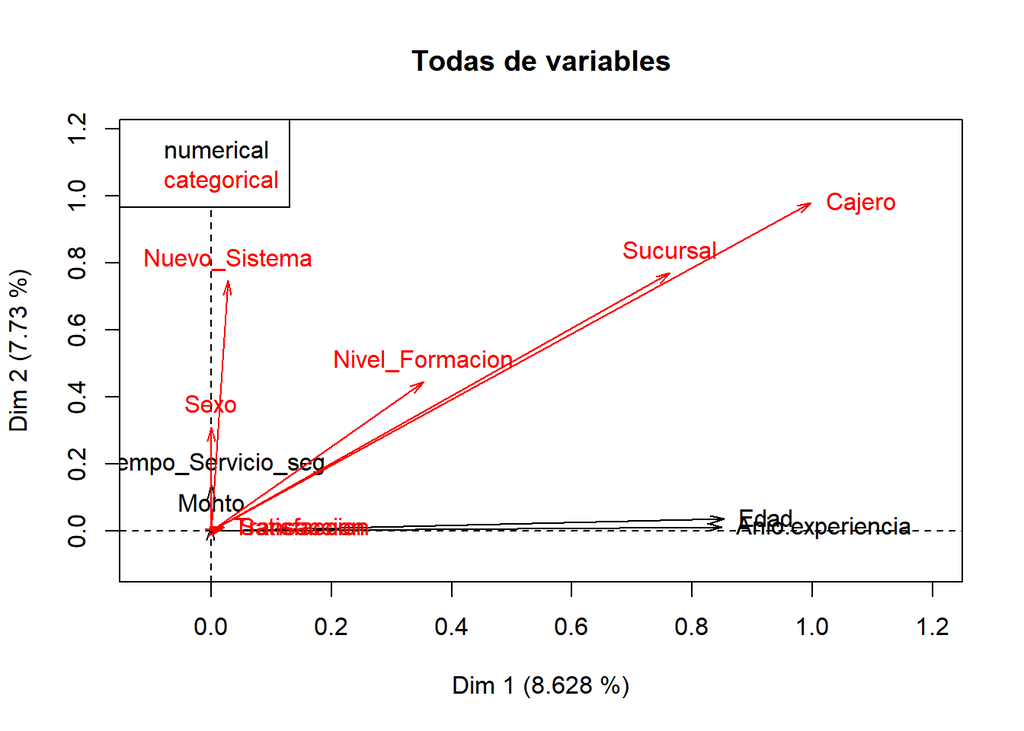

```r
plot(pcamix,choice="sqload",coloring.var=T, leg=TRUE,
posleg="topleft", main="Todas de variables")
```

En el siguiente gráfico se muestra el mapa de componentes principales y se puede observar la concentración de datos en 2 dimensiones.

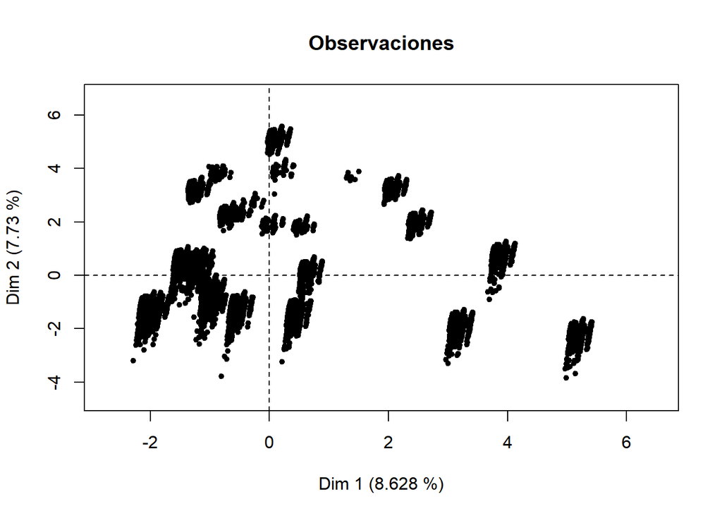

```r
plot(pcamix,choice="ind",coloring.var = T,label=FALSE,posleg="bottomright", main="Observaciones")
```

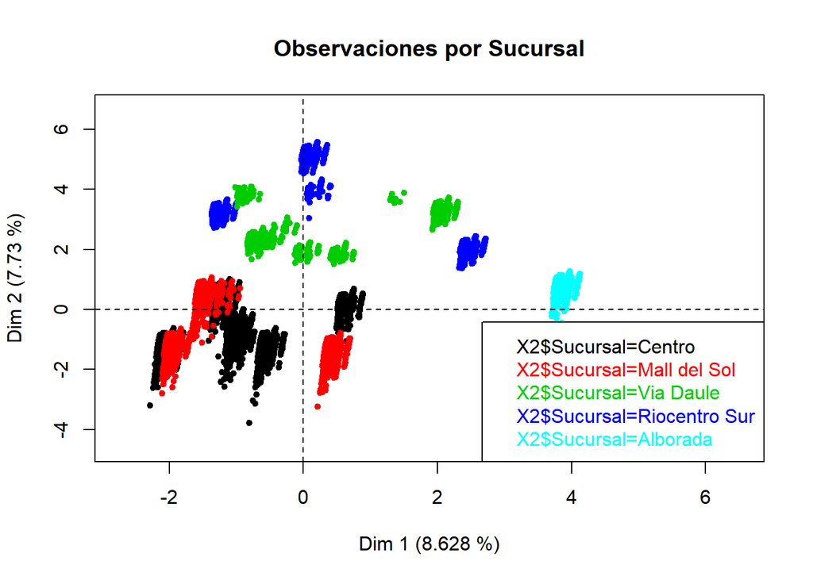

```r
plot(pcamix,choice="ind",coloring.ind=X2$Sucursal,label=FALSE,
posleg="bottomright", main="Observaciones por Sucursal")
```

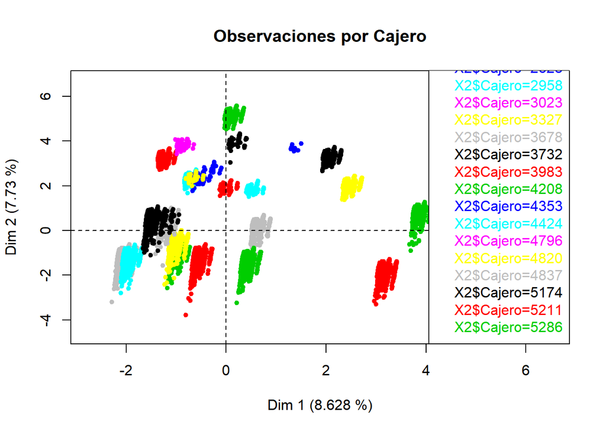

```r
plot(pcamix,choice="ind",coloring.ind=X2$Cajero,label=FALSE,
posleg="bottomright", main="Observaciones por Cajero")
```

La siguiente gráfica indica un círculo de correlación, en este caso se tiene una correlación negativa

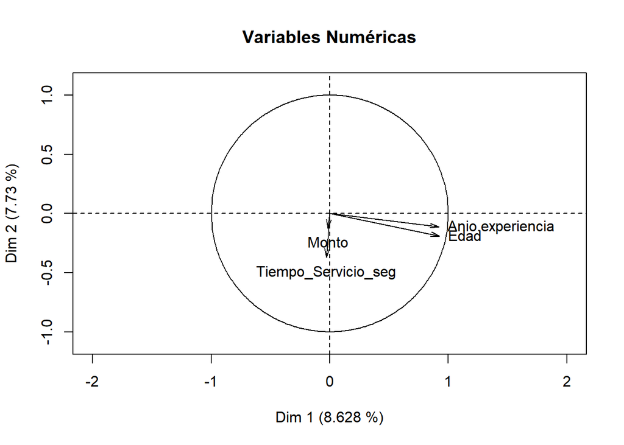

```r
plot(pcamix,choice="cor",main="Variables Numéricas")
```

## Rotación

Usaremos la función PCArot para simpificar la interpretación de los datos de las componente principales.

### Muestra de Entrenamiento

```r
train <- datos[-c(1:10000), ]
split <- splitmix(train)
X1 <- split$X.quanti
X2 <- split$X.quali
res.pcamix <- PCAmix(X.quanti=X1, X.quali=X2,rename.level=TRUE, graph=FALSE)
res.pcamix$eig
```

```
##        Eigenvalue Proportion Cumulative
## dim 1   4.9115171  11.979310   11.97931
## dim 2   4.1424347  10.103499   22.08281
## dim 3   3.0396680   7.413824   29.49663
## dim 4   2.6664973   6.503652   36.00029
## dim 5   2.1666645   5.284548   41.28483
## dim 6   1.9680923   4.800225   46.08506
## dim 7   1.9547408   4.767660   50.85272
## dim 8   1.5427438   3.762790   54.61551
## dim 9   1.2463732   3.039935   57.65544
## dim 10  1.0509042   2.563181   60.21862
## dim 11  1.0354092   2.525388   62.74401
## dim 12  1.0330748   2.519695   65.26371
## dim 13  1.0198739   2.487497   67.75120
## dim 14  1.0148018   2.475126   70.22633
## dim 15  1.0079113   2.458320   72.68465
## dim 16  1.0021549   2.444280   75.12893
## dim 17  1.0001073   2.439286   77.56822
## dim 18  1.0000000   2.439024   80.00724
## dim 19  1.0000000   2.439024   82.44627
## dim 20  0.9986906   2.435831   84.88210
## dim 21  0.9907197   2.416389   87.29849
## dim 22  0.9832513   2.398174   89.69666
## dim 23  0.9704124   2.366859   92.06352
## dim 24  0.9606042   2.342937   94.40646
## dim 25  0.9482734   2.312862   96.71932
## dim 26  0.8412019   2.051712   98.77103
## dim 27  0.5038777   1.228970  100.00000
```

A partir de la dim 10 ya se tiene un acumulado de 60.22% del total de inercia.

En la dim 5 se tiene una acumulado de 41.28%

```r
res.pcarot<-PCArot(res.pcamix,dim=5,graph=FALSE)
res.pcarot$eig #variance of the rotated PCs
```

```
##          Variance Proportion
## dim1.rot 4.844300  11.815367
## dim2.rot 3.198740   7.801804
## dim3.rot 3.430693   8.367544
## dim4.rot 3.034382   7.400932
## dim5.rot 2.418666   5.899185
```

```r
sum(res.pcarot$eig[,2])
```

```
## [1] 41.28483
```

```r
res.pcamix$sqload[,1:5]
```

```
##                           dim 1        dim 2        dim 3        dim 4
## ID_Sucursal         0.004175938 0.7630354916 7.005200e-02 0.1074878116
## Tiempo_Servicio_seg 0.021774744 0.0404938966 2.765478e-01 0.0050944973
## Monto               0.001545770 0.0030817759 3.750790e-02 0.0005290572
## Edad                0.902560183 0.0001569882 4.592432e-02 0.0014092131
## Anio.Ingreso        0.906336799 0.0128037525 5.369638e-05 0.0116284431
## Anio.experiencia    0.906336799 0.0128037525 5.369638e-05 0.0116284431
## Cajero              0.987801955 0.9939373993 7.450090e-01 0.9857182307
## ID_Transaccion      0.055749243 0.0075612181 3.462681e-01 0.0246833459
## Transaccion         0.055749243 0.0075612181 3.462681e-01 0.0246833459
## Satisfaccion        0.038010272 0.0271279397 1.141127e-02 0.0013922802
## Sucursal            0.756095218 0.8476385261 6.855806e-01 0.1565253178
## Nuevo_Sistema       0.017984530 0.5919521693 1.990983e-01 0.0765098974
## Sexo                0.016548451 0.3648177764 4.517010e-03 0.6033803325
## Nivel_Formacion     0.240847906 0.4694627976 2.713761e-01 0.6558270672
##                           dim 5
## ID_Sucursal         0.001051927
## Tiempo_Servicio_seg 0.210072484
## Monto               0.034127344
## Edad                0.001005330
## Anio.Ingreso        0.001888875
## Anio.experiencia    0.001888875
## Cajero              0.226159229
## ID_Transaccion      0.660533115
## Transaccion         0.660533115
## Satisfaccion        0.013728697
## Sucursal            0.146030039
## Nuevo_Sistema       0.077408571
## Sexo                0.002837907
## Nivel_Formacion     0.129399024
```

```r
res.pcarot$sqload
```

```
##                         dim1.rot     dim2.rot     dim3.rot     dim4.rot
## ID_Sucursal         0.0002638999 0.5914230306 3.318841e-01 2.067749e-02
## Tiempo_Servicio_seg 0.0033380145 0.0043371066 7.694842e-02 4.868704e-04
## Monto               0.0000529760 0.0009101318 6.492956e-03 1.658063e-05
## Edad                0.8905455590 0.0483546514 6.851128e-05 1.197351e-02
## Anio.Ingreso        0.9216968396 0.0057068465 1.664012e-04 3.071847e-03
## Anio.experiencia    0.9216968396 0.0057068465 1.664012e-04 3.071847e-03
## Cajero              0.9904749001 0.9378781810 9.819627e-01 9.950684e-01
## ID_Transaccion      0.0449816132 0.1285896107 1.739094e-02 3.293595e-03
## Transaccion         0.0449816132 0.1285896107 1.739094e-02 3.293595e-03
## Satisfaccion        0.0442681430 0.0013128941 1.027419e-02 1.637383e-02
## Sucursal            0.7826789477 0.8265382670 9.433011e-01 2.846919e-02
## Nuevo_Sistema       0.0006118266 0.0093335736 9.417124e-01 8.656887e-03
## Sexo                0.0024570436 0.0139495237 7.859189e-03 9.678351e-01
## Nivel_Formacion     0.1962522785 0.4961095671 9.507476e-02 9.720936e-01
##                         dim5.rot
## ID_Sucursal         1.554656e-03
## Tiempo_Servicio_seg 4.688730e-01
## Monto               6.931920e-02
## Edad                1.138100e-04
## Anio.Ingreso        2.069633e-03
## Anio.experiencia    2.069633e-03
## Cajero              3.324171e-02
## ID_Transaccion      9.005393e-01
## Transaccion         9.005393e-01
## Satisfaccion        1.944140e-02
## Sucursal            1.088224e-02
## Nuevo_Sistema       2.638851e-03
## Sexo                6.085700e-07
## Nivel_Formacion     7.382750e-03
```

Pero se puede observar que en este caso no mejora la interpretación de los datos. Debido a esto se procede a realizar indicadores respecto a la satisfacción ya que estos problemas de que no se encuentra una mejora sea debido a la repetición de datos.

```r
#Obtencion de indicadores para satisfaccion

#Para cajero
indicador_cajero <- datos %>% mutate(Peso=ifelse(Satisfaccion=="Muy Malo",1,
                                          ifelse(Satisfaccion=="Malo",2,
                                                 ifelse(Satisfaccion=="Regular",3,
                                                        ifelse(Satisfaccion=="Bueno",4,5))))) %>%
  group_by(Cajero,Satisfaccion) %>% summarise(Total=n(), Peso=sum(Peso))
indicador_cajero <- indicador_cajero %>% group_by(Cajero) %>%
  summarise(indicador_cajero=(sum(Peso)/sum(Total)))
datos <- left_join(datos,indicador_cajero)
#Para sucursales
indicador_sucursal <- datos %>% mutate(Peso=ifelse(Satisfaccion=="Muy Malo",1,
                                                      ifelse(Satisfaccion=="Malo",2,
                                                             ifelse(Satisfaccion=="Regular",3,
                                                                    ifelse(Satisfaccion=="Bueno",4,5))))) %>%
  group_by(Sucursal,Satisfaccion) %>% summarise(Total=n(), Peso=sum(Peso))
indicador_sucursal <- indicador_sucursal %>% group_by(Sucursal) %>%
  summarise(indicador_sucursal=(sum(Peso)/sum(Total)))
datos <- left_join(datos,indicador_sucursal)
data<- select(datos,-ID_Sucursal,-Anio.Ingreso,-ID_Transaccion)
```

Aplicación de la función splitmix

```r
split <- splitmix(data)
X1 <- split$X.quanti
X2 <- split$X.quali
res1.pcamix <- PCAmix(X.quanti=X1, X.quali=X2,rename.level=TRUE,graph=FALSE)
res1.pcamix$eig
```

```
##        Eigenvalue Proportion Cumulative
## dim 1   5.2370089 11.1425722   11.14257
## dim 2   3.5432640  7.5388596   18.68143
## dim 3   2.6793700  5.7007873   24.38222
## dim 4   2.3355278  4.9692082   29.35143
## dim 5   2.1335822  4.5395365   33.89096
## dim 6   1.9244841  4.0946471   37.98561
## dim 7   1.7926854  3.8142243   41.79984
## dim 8   1.5280958  3.2512676   45.05110
## dim 9   1.4013985  2.9816989   48.03280
## dim 10  1.1497600  2.4462979   50.47910
## dim 11  1.0755076  2.2883140   52.76741
## dim 12  1.0477738  2.2293061   54.99672
## dim 13  1.0398360  2.2124169   57.20914
## dim 14  1.0303612  2.1922578   59.40139
## dim 15  1.0184181  2.1668471   61.56824
## dim 16  1.0113756  2.1518629   63.72010
## dim 17  1.0031590  2.1343808   65.85449
## dim 18  1.0001430  2.1279639   67.98245
## dim 19  1.0000000  2.1276596   70.11011
## dim 20  1.0000000  2.1276596   72.23777
## dim 21  1.0000000  2.1276596   74.36543
## dim 22  1.0000000  2.1276596   76.49309
## dim 23  1.0000000  2.1276596   78.62075
## dim 24  1.0000000  2.1276596   80.74841
## dim 25  1.0000000  2.1276596   82.87607
## dim 26  1.0000000  2.1276596   85.00373
## dim 27  0.9977379  2.1228465   87.12657
## dim 28  0.9809821  2.0871960   89.21377
## dim 29  0.9740885  2.0725286   91.28630
## dim 30  0.9671704  2.0578093   93.34411
## dim 31  0.9574938  2.0372208   95.38133
## dim 32  0.9238581  1.9656555   97.34698
## dim 33  0.8310622  1.7682174   99.11520
## dim 34  0.4158561  0.8848002  100.00000
```

```r
res1.pcamix$sqload
```

```
##                           dim 1       dim 2       dim 3        dim 4
## Tiempo_Servicio_seg 0.014104810 0.107573703 0.055274064 0.0398874832
## Monto               0.001574274 0.011212002 0.009303057 0.0061291338
## Edad                0.596262273 0.244874703 0.018310167 0.0195417025
## Anio.experiencia    0.677812738 0.171194065 0.008196388 0.0001238201
## indicador_cajero    0.633502167 0.021484857 0.109578584 0.0169939779
## indicador_sucursal  0.882899655 0.001417610 0.035558166 0.0025887161
## Cajero              0.997876520 0.985651588 0.984999032 0.9713392776
## Transaccion         0.013291299 0.011804926 0.010061907 0.0473940830
## Satisfaccion        0.035106350 0.003332122 0.006775898 0.0078598455
## Sucursal            0.884593303 0.720501804 0.198010250 0.6230813774
## Nuevo_Sistema       0.205974649 0.555519895 0.171185309 0.0206996106
## Sexo                0.039301793 0.286047623 0.496542188 0.0146171906
## Nivel_Formacion     0.254709096 0.422649092 0.575575041 0.5652716256
##                           dim 5
## Tiempo_Servicio_seg 0.020532837
## Monto               0.005631196
## Edad                0.024092067
## Anio.experiencia    0.006323757
## indicador_cajero    0.034714276
## indicador_sucursal  0.008471731
## Cajero              0.974634690
## Transaccion         0.056857383
## Satisfaccion        0.001053047
## Sucursal            0.592591842
## Nuevo_Sistema       0.006340693
## Sexo                0.014243571
## Nivel_Formacion     0.388095084
```

Por otra parte se nota un aumento en la dim 5 de las variables por lo que se procede a verificar en los gráficos

## Gráficos

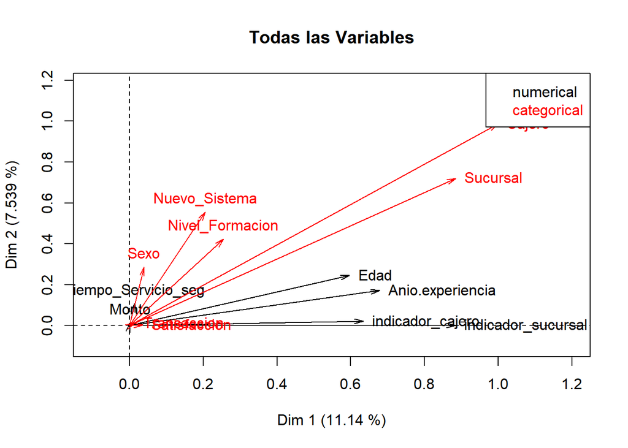

```r
plot(res1.pcamix,choice="sqload",coloring.var=T, leg=TRUE,
posleg="topright", main="Todas las Variables")
```

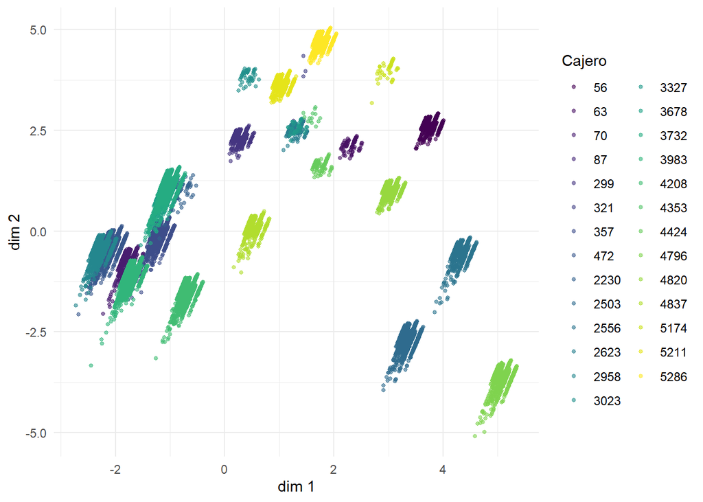

```r
df_pca = cbind(data,res1.pcamix$scores)

ggplot(df_pca) +
 aes(x = `dim 1`, y = `dim 2`, colour = Cajero) +
 geom_point(size = 1L, alpha=0.6)+
 scale_color_viridis_d() +
 theme_minimal()
```

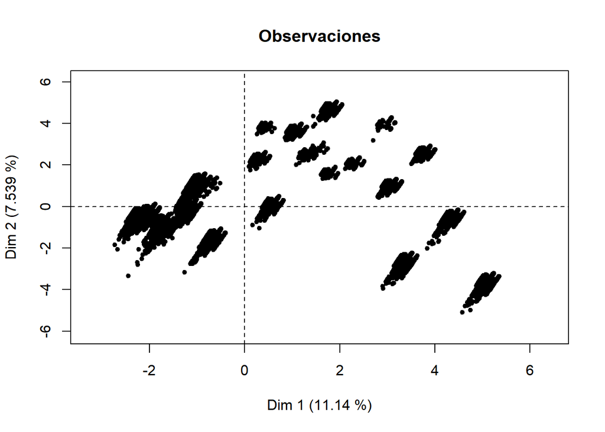

```r
plot(res1.pcamix,choice="ind",coloring.var = T,label=FALSE,posleg="bottomright", main="Observaciones")
```

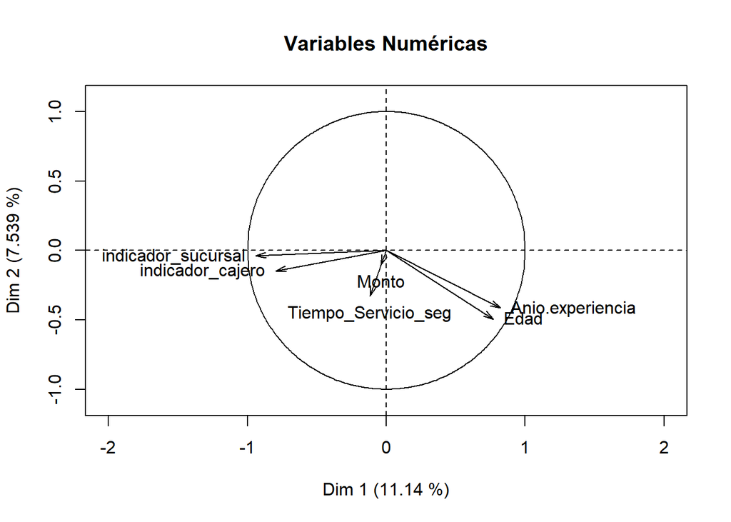

```r
plot(res1.pcamix,choice="cor",main="Variables Numéricas")
```